# Binary-Class Tabular Model for Kaggle Tabular Playground 2022 August Using Python and TensorFlow

### September 1, 2022

SUMMARY: The project aims to construct a predictive model using various machine learning algorithms and document the end-to-end steps using a template. The Kaggle Tabular Playground 2022 August dataset is a binary-class modeling situation where we attempt to predict one of two possible outcomes.

INTRODUCTION: Kaggle wants to provide an approachable environment for relatively new people in their data science journey. Since January 2021, they have hosted playground-style competitions on Kaggle with fun but less complex, tabular datasets. This data represents the results of an extensive product testing study. For each product code, the research team provided product attributes and measurement values for each product, representing various lab testing methods.

Each product is used in a simulated real-world environment experiment and absorbs a certain amount of fluid to see whether it fails. The project task is to use the data to predict individual product failures of new codes with their lab test results.

ANALYSIS: The average performance of the preliminary TensorFlow models achieved a ROC_AUC benchmark of 0.5742. When we processed the test dataset with the final model, the model achieved a ROC_AUC score of 0.5700.

CONCLUSION: In this iteration, TensorFlow appeared to be a suitable algorithm for modeling this dataset.

Dataset Used: Kaggle Tabular Playground 2022 August

Dataset ML Model: Binary classification with numerical features

Dataset Reference: https://www.kaggle.com/competitions/tabular-playground-series-aug-2022

One source of potential performance benchmarks: https://www.kaggle.com/competitions/tabular-playground-series-aug-2022/leaderboard

## Task 1 - Prepare Environment

```python
# Retrieve the GPU information
gpu_info = !nvidia-smi
gpu_info = '\n'.join(gpu_info)
print(gpu_info)
```

```
Sun Aug 21 03:09:28 2022
+-----------------------------------------------------------------------------+
| NVIDIA-SMI 460.32.03    Driver Version: 460.32.03    CUDA Version: 11.2     |
|-------------------------------+----------------------+----------------------+
| GPU  Name        Persistence-M| Bus-Id        Disp.A | Volatile Uncorr. ECC |
| Fan  Temp  Perf  Pwr:Usage/Cap|         Memory-Usage | GPU-Util  Compute M. |
|                               |                      |               MIG M. |
|===============================+======================+======================|
|   0  A100-SXM4-40GB      Off  | 00000000:00:04.0 Off |                    0 |
| N/A   35C    P0    45W / 400W |      0MiB / 40536MiB |      0%      Default |
|                               |                      |             Disabled |
+-------------------------------+----------------------+----------------------+

+-----------------------------------------------------------------------------+
| Processes:                                                                  |
|  GPU   GI   CI        PID   Type   Process name                  GPU Memory |
|        ID   ID                                                   Usage      |
|=============================================================================|
|  No running processes found                                                 |
+-----------------------------------------------------------------------------+
```

```python
# Retrieve the memory configuration
from psutil import virtual_memory
ram_gb = virtual_memory().total / 1e9
print('Your runtime has {:.1f} gigabytes of available RAM\n'.format(ram_gb))
```

```
Your runtime has 89.6 gigabytes of available RAM
```

```python
# Retrieve the CPU information
ncpu = !nproc
print("The number of available CPUs is:", ncpu[0])
```

```
The number of available CPUs is: 12
```

### 1.a) Load libraries and modules

```python
# Set the random seed number for reproducible results
RNG_SEED = 888
```

```python
import random
random.seed(RNG_SEED)
import numpy as np
np.random.seed(RNG_SEED)
import pandas as pd
import seaborn as sns
import matplotlib.pyplot as plt
import os
import sys
import math
# import boto3
import zipfile
from datetime import datetime
from sklearn import preprocessing
from sklearn.model_selection import train_test_split
from sklearn.model_selection import RepeatedKFold
from sklearn.model_selection import cross_val_score
from sklearn.metrics import classification_report
from sklearn.metrics import confusion_matrix
from sklearn.metrics import accuracy_score
from sklearn.pipeline import Pipeline
from sklearn import compose
from sklearn import impute

from sklearn.feature_selection import RFE
from imblearn.pipeline import Pipeline
from imblearn.over_sampling import SMOTE
from imblearn.under_sampling import RandomUnderSampler

import tensorflow as tf
tf.random.set_seed(RNG_SEED)
from tensorflow import keras
from tensorflow.keras.callbacks import ReduceLROnPlateau
```

### 1.b) Set up the controlling parameters and functions

```python
# Begin the timer for the script processing
START_TIME_SCRIPT = datetime.now()
```

```python
# Set up the number of CPU cores available for multi-thread processing
N_JOBS = 1

# Set up the flag to stop sending progress emails (setting to True will send status emails!)
NOTIFY_STATUS = False

# Set the percentage sizes for splitting the dataset
# TEST_SET_RATIO = 0.2
# VAL_SET_RATIO = 0.2

# Set the name for the class/label column
ORIGINAL_LABEL = 'failure'
CLASS_COLUMN = 'target'

# Set the number of folds for cross validation
N_FOLDS = 5
N_ITERATIONS = 1

# Set various default modeling parameters
DEFAULT_LOSS = 'binary_crossentropy'
DEFAULT_METRICS = [tf.keras.metrics.AUC()]
DEFAULT_OPTIMIZER = tf.keras.optimizers.Adam(learning_rate=0.0001)
CLASSIFIER_ACTIVATION = 'sigmoid'
MAX_EPOCHS = 20
BATCH_SIZE = 32
NUM_CLASSES = 1

# Define the labels to use for graphing the data
TRAIN_METRIC = "auc"
VALIDATION_METRIC = "val_auc"
TRAIN_LOSS = "loss"
VALIDATION_LOSS = "val_loss"

# Define the directory locations and file names
TRAIN_DATASET = 'https://dainesanalytics.com/datasets/kaggle-tabular-playground-2022aug/train.csv'
TEST_DATASET = 'https://dainesanalytics.com/datasets/kaggle-tabular-playground-2022aug/test.csv'

# Check the number of GPUs accessible through TensorFlow
print('Num GPUs Available:', len(tf.config.list_physical_devices('GPU')))

# Print out the TensorFlow version for confirmation
print('TensorFlow version:', tf.__version__)
```

```
Num GPUs Available: 1
TensorFlow version: 2.8.2
```

```python
# Set up the email notification function
def status_notify(msg_text):
    access_key = os.environ.get('SNS_ACCESS_KEY')
    secret_key = os.environ.get('SNS_SECRET_KEY')
    aws_region = os.environ.get('SNS_AWS_REGION')
    topic_arn = os.environ.get('SNS_TOPIC_ARN')
    if (access_key is None) or (secret_key is None) or (aws_region is None):
        sys.exit("Incomplete notification setup info. Script Processing Aborted!!!")
    sns = boto3.client('sns', aws_access_key_id=access_key, aws_secret_access_key=secret_key, region_name=aws_region)
    response = sns.publish(TopicArn=topic_arn, Message=msg_text)
    if response['ResponseMetadata']['HTTPStatusCode'] != 200 :
        print('Status notification not OK with HTTP status code:', response['ResponseMetadata']['HTTPStatusCode'])
```

```python
if NOTIFY_STATUS: status_notify("Task 1 - Prepare Environment has begun! " + datetime.now().strftime('%a %B %d, %Y %I:%M:%S %p'))
```

### 1.c) Load dataset

```python
df_dataset_import = pd.read_csv(TRAIN_DATASET)

# Take a peek at the dataframe after import
print(df_dataset_import.head())
```

```
   id product_code  loading attribute_0 attribute_1  attribute_2  attribute_3  \
0   0            A    80.10  material_7  material_8            9            5
1   1            A    84.89  material_7  material_8            9            5
2   2            A    82.43  material_7  material_8            9            5
3   3            A   101.07  material_7  material_8            9            5
4   4            A   188.06  material_7  material_8            9            5

   measurement_0  measurement_1  measurement_2  ...  measurement_9  \
0              7              8              4  ...         10.672
1             14              3              3  ...         12.448
2             12              1              5  ...         12.715
3             13              2              6  ...         12.471
4              9              2              8  ...         10.337

   measurement_10  measurement_11  measurement_12  measurement_13  \
0          15.859          17.594          15.193          15.029
1          17.947          17.915          11.755          14.732
2          15.607             NaN          13.798          16.711
3          16.346          18.377          10.020          15.250
4          17.082          19.932          12.428          16.182

   measurement_14  measurement_15  measurement_16  measurement_17  failure
0             NaN          13.034          14.684         764.100        0
1          15.425          14.395          15.631         682.057        0
2          18.631          14.094          17.946         663.376        0
3          15.562          16.154          17.172         826.282        0
4          12.760          13.153          16.412         579.885        0

[5 rows x 26 columns]
```

```python
df_dataset_import.info(verbose=True)
```

```
<class 'pandas.core.frame.DataFrame'>
RangeIndex: 26570 entries, 0 to 26569
Data columns (total 26 columns):
 #   Column          Non-Null Count  Dtype
---  ------          --------------  -----
 0   id              26570 non-null  int64
 1   product_code    26570 non-null  object
 2   loading         26320 non-null  float64
 3   attribute_0     26570 non-null  object
 4   attribute_1     26570 non-null  object
 5   attribute_2     26570 non-null  int64
 6   attribute_3     26570 non-null  int64
 7   measurement_0   26570 non-null  int64
 8   measurement_1   26570 non-null  int64
 9   measurement_2   26570 non-null  int64
```

[output cut: 18 more lines]

```python
print(df_dataset_import.describe())
```

```
                 id       loading   attribute_2   attribute_3  measurement_0  \
count  26570.000000  26320.000000  26570.000000  26570.000000   26570.000000
mean   13284.500000    127.826233      6.754046      7.240459       7.415883
std     7670.242662     39.030020      1.471852      1.456493       4.116690
min        0.000000     33.160000      5.000000      5.000000       0.000000
25%     6642.250000     99.987500      6.000000      6.000000       4.000000
50%    13284.500000    122.390000      6.000000      8.000000       7.000000
75%    19926.750000    149.152500      8.000000      8.000000      10.000000
max    26569.000000    385.860000      9.000000      9.000000      29.000000

       measurement_1  measurement_2  measurement_3  measurement_4  \
count   26570.000000   26570.000000   26189.000000   26032.000000
mean        8.232518       6.256568      17.791528      11.731988
std         4.199401       3.309109       1.001200       0.996085
min         0.000000       0.000000      13.968000       8.008000
25%         5.000000       4.000000      17.117000      11.051000
50%         8.000000       6.000000      17.787000      11.733000
75%        11.000000       8.000000      18.469000      12.410000
max        29.000000      24.000000      21.499000      16.484000

       measurement_5  ...  measurement_9  measurement_10  measurement_11  \
count   25894.000000  ...   25343.000000    25270.000000    25102.000000
mean       17.127804  ...      11.430725       16.117711       19.172085
std         0.996414  ...       0.999137        1.405978        1.520785
min        12.073000  ...       7.537000        9.323000       12.461000
25%        16.443000  ...      10.757000       15.209000       18.170000
50%        17.132000  ...      11.430000       16.127000       19.211500
75%        17.805000  ...      12.102000       17.025000       20.207000
max        21.425000  ...      15.412000       22.479000       25.640000

       measurement_12  measurement_13  measurement_14  measurement_15  \
count    24969.000000    24796.000000    24696.000000    24561.000000
mean        11.702464       15.652904       16.048444       14.995554
std          1.488838        1.155247        1.491923        1.549226
min          5.167000       10.890000        9.140000        9.104000
25%         10.703000       14.890000       15.057000       13.957000
50%         11.717000       15.628500       16.040000       14.969000
75%         12.709000       16.374000       17.082000       16.018000
max         17.663000       22.713000       22.303000       21.626000

       measurement_16  measurement_17       failure
count    24460.000000    24286.000000  26570.000000
mean        16.460727      701.269059      0.212608
std          1.708935      123.304161      0.409160
min          9.701000      196.787000      0.000000
25%         15.268000      618.961500      0.000000
50%         16.436000      701.024500      0.000000
75%         17.628000      784.090250      0.000000
max         24.094000     1312.794000      1.000000

[8 rows x 23 columns]
```

```python
print(df_dataset_import.isnull().sum())
print('Total number of NaN in the dataframe: ', df_dataset_import.isnull().sum().sum())
```

```
id                   0
product_code         0
loading            250
attribute_0          0
attribute_1          0
attribute_2          0
attribute_3          0
measurement_0        0
measurement_1        0
measurement_2        0
measurement_3      381
measurement_4      538
measurement_5      676
measurement_6      796
measurement_7      937
measurement_8     1048
measurement_9     1227
measurement_10    1300
measurement_11    1468
measurement_12    1601
measurement_13    1774
measurement_14    1874
measurement_15    2009
measurement_16    2110
measurement_17    2284
failure              0
dtype: int64
Total number of NaN in the dataframe:  20273
```

```python
# Get grouping size for the target variable
print(df_dataset_import.groupby(ORIGINAL_LABEL).size())
```

```
failure
0    20921
1     5649
dtype: int64
```

### 1.d) Data Cleaning

```python
# Dropping unique or redundant features
df_dataset_import.drop(columns=['id'], inplace=True)

# Convert columns from one data type to another
df_dataset_import['attribute_0'] = df_dataset_import['attribute_0'].astype('category')
df_dataset_import['attribute_1'] = df_dataset_import['attribute_1'].astype('category')
df_dataset_import['attribute_2'] = df_dataset_import['attribute_2'].astype('category')
df_dataset_import['attribute_3'] = df_dataset_import['attribute_3'].astype('category')

# Standardize the class column to the name of targetVar if required
df_dataset_import = df_dataset_import.rename(columns={ORIGINAL_LABEL: CLASS_COLUMN})

# Take a peek at the dataframe after cleaning
print(df_dataset_import.head())
```

```
  product_code  loading attribute_0 attribute_1 attribute_2 attribute_3  \
0            A    80.10  material_7  material_8           9           5
1            A    84.89  material_7  material_8           9           5
2            A    82.43  material_7  material_8           9           5
3            A   101.07  material_7  material_8           9           5
4            A   188.06  material_7  material_8           9           5

   measurement_0  measurement_1  measurement_2  measurement_3  ...  \
0              7              8              4         18.040  ...
1             14              3              3         18.213  ...
2             12              1              5         18.057  ...
3             13              2              6         17.295  ...
4              9              2              8         19.346  ...

   measurement_9  measurement_10  measurement_11  measurement_12  \
```

[output cut: 21 more lines]

```python
df_dataset_import.info(verbose=True)
```

```
<class 'pandas.core.frame.DataFrame'>
RangeIndex: 26570 entries, 0 to 26569
Data columns (total 25 columns):
 #   Column          Non-Null Count  Dtype
---  ------          --------------  -----
 0   product_code    26570 non-null  object
 1   loading         26320 non-null  float64
 2   attribute_0     26570 non-null  category
 3   attribute_1     26570 non-null  category
 4   attribute_2     26570 non-null  category
 5   attribute_3     26570 non-null  category
 6   measurement_0   26570 non-null  int64
 7   measurement_1   26570 non-null  int64
 8   measurement_2   26570 non-null  int64
 9   measurement_3   26189 non-null  float64
```

[output cut: 17 more lines]

```python
print(df_dataset_import.describe())
```

```
            loading  measurement_0  measurement_1  measurement_2  \
count  26320.000000   26570.000000   26570.000000   26570.000000
mean     127.826233       7.415883       8.232518       6.256568
std       39.030020       4.116690       4.199401       3.309109
min       33.160000       0.000000       0.000000       0.000000
25%       99.987500       4.000000       5.000000       4.000000
50%      122.390000       7.000000       8.000000       6.000000
75%      149.152500      10.000000      11.000000       8.000000
max      385.860000      29.000000      29.000000      24.000000

       measurement_3  measurement_4  measurement_5  measurement_6  \
count   26189.000000   26032.000000   25894.000000   25774.000000
mean       17.791528      11.731988      17.127804      17.510759
std         1.001200       0.996085       0.996414       0.995980
min        13.968000       8.008000      12.073000      12.715000
25%        17.117000      11.051000      16.443000      16.839000
50%        17.787000      11.733000      17.132000      17.516000
75%        18.469000      12.410000      17.805000      18.178000
max        21.499000      16.484000      21.425000      21.543000

       measurement_7  measurement_8  measurement_9  measurement_10  \
count   25633.000000   25522.000000   25343.000000    25270.000000
mean       11.716624      19.024714      11.430725       16.117711
std         1.000836       1.008591       0.999137        1.405978
min         7.968000      15.217000       7.537000        9.323000
25%        11.045000      18.340250      10.757000       15.209000
50%        11.712000      19.021000      11.430000       16.127000
75%        12.391000      19.708000      12.102000       17.025000
max        15.419000      23.807000      15.412000       22.479000

       measurement_11  measurement_12  measurement_13  measurement_14  \
count    25102.000000    24969.000000    24796.000000    24696.000000
mean        19.172085       11.702464       15.652904       16.048444
std          1.520785        1.488838        1.155247        1.491923
min         12.461000        5.167000       10.890000        9.140000
25%         18.170000       10.703000       14.890000       15.057000
50%         19.211500       11.717000       15.628500       16.040000
75%         20.207000       12.709000       16.374000       17.082000
max         25.640000       17.663000       22.713000       22.303000

       measurement_15  measurement_16  measurement_17        target
count    24561.000000    24460.000000    24286.000000  26570.000000
mean        14.995554       16.460727      701.269059      0.212608
std          1.549226        1.708935      123.304161      0.409160
min          9.104000        9.701000      196.787000      0.000000
25%         13.957000       15.268000      618.961500      0.000000
50%         14.969000       16.436000      701.024500      0.000000
75%         16.018000       17.628000      784.090250      0.000000
max         21.626000       24.094000     1312.794000      1.000000
```

```python
print(df_dataset_import.isnull().sum())
print('Total number of NaN in the dataframe: ', df_dataset_import.isnull().sum().sum())
```

```
product_code         0
loading            250
attribute_0          0
attribute_1          0
attribute_2          0
attribute_3          0
measurement_0        0
measurement_1        0
measurement_2        0
measurement_3      381
measurement_4      538
measurement_5      676
measurement_6      796
measurement_7      937
measurement_8     1048
measurement_9     1227
measurement_10    1300
measurement_11    1468
measurement_12    1601
measurement_13    1774
measurement_14    1874
measurement_15    2009
measurement_16    2110
measurement_17    2284
target               0
dtype: int64
Total number of NaN in the dataframe:  20273
```

```python
# Get grouping size for the target variable
print(df_dataset_import.groupby(CLASS_COLUMN).size())
```

```
target
0    20921
1     5649
dtype: int64
```

### 1.e) Splitting Data into Sets

```python
# Use variable total_column_count to hold the number of columns in the dataframe
total_column_count = len(df_dataset_import.columns)

# Set up variable total_feature_count for the total number of attribute columns
total_feature_count = total_column_count-1

# We create attribute-only and target-only datasets (df_features_train and df_target_train)
df_target_train = df_dataset_import['target']
df_features_train = df_dataset_import.drop(['target'], axis=1)

print("df_dataset_import.shape: {} df_features_train.shape: {} df_target_train.shape: {}".format(df_dataset_import.shape, df_features_train.shape, df_target_train.shape))
```

```
df_dataset_import.shape: (26570, 25) df_features_train.shape: (26570, 24) df_target_train.shape: (26570,)
```

### 1.f) Set up the parameters for data visualization

```python
# Set up the number of row and columns for visualization display. display_rows * display_columns should be >= total_feature_count
display_columns = 4
if total_feature_count % display_columns == 0 :
    display_rows = total_feature_count // display_columns
else :
    display_rows = (total_feature_count // display_columns) + 1

# Set figure width to display the data visualization plots
fig_size = plt.rcParams["figure.figsize"]
fig_size[0] = display_columns * 4
fig_size[1] = display_rows * 4
plt.rcParams["figure.figsize"] = fig_size
```

```python
if NOTIFY_STATUS: status_notify("Task 1 - Prepare Environment completed! " + datetime.now().strftime('%a %B %d, %Y %I:%M:%S %p'))
```

## Task 2 - Summarize and Visualize Data

```python
if NOTIFY_STATUS: status_notify("Task 2 - Summarize and Visualize Data has begun! " + datetime.now().strftime('%a %B %d, %Y %I:%M:%S %p'))
```

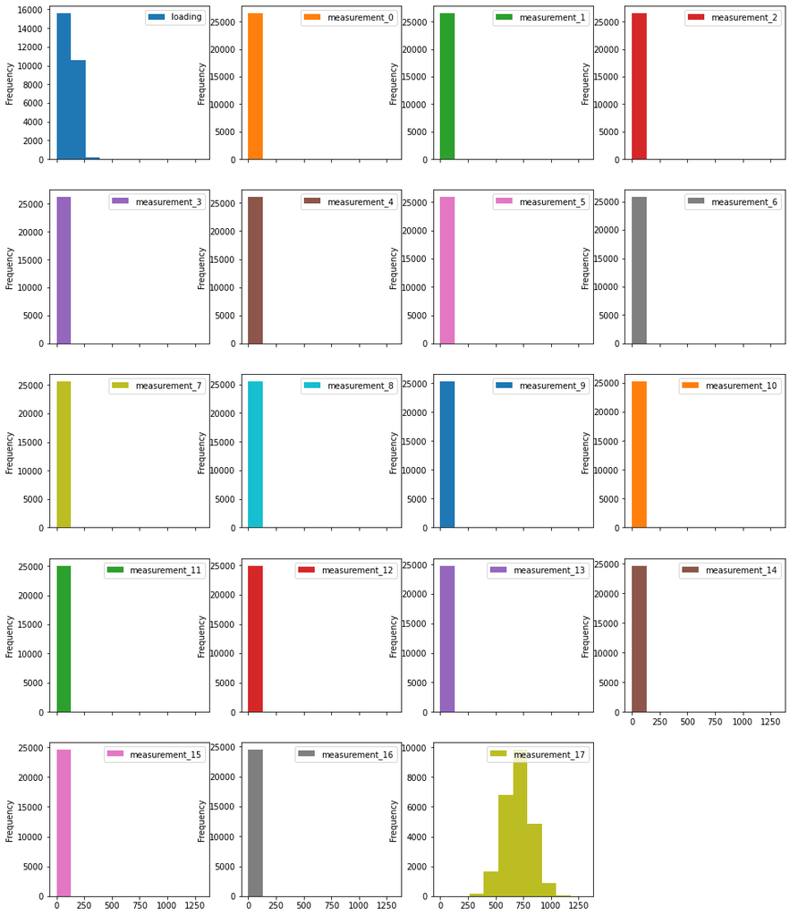

```python
# Histograms for each attribute
df_features_train.plot(kind='hist', subplots=True, layout=(display_rows, display_columns))
plt.show()
```

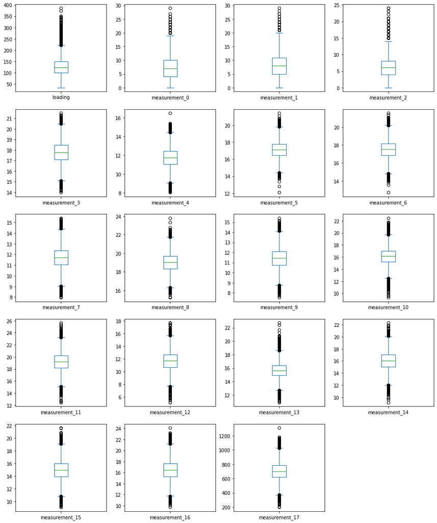

```python
# Box and Whisker plot for each attribute
df_features_train.plot(kind='box', subplots=True, layout=(display_rows, display_columns))
plt.show()
```

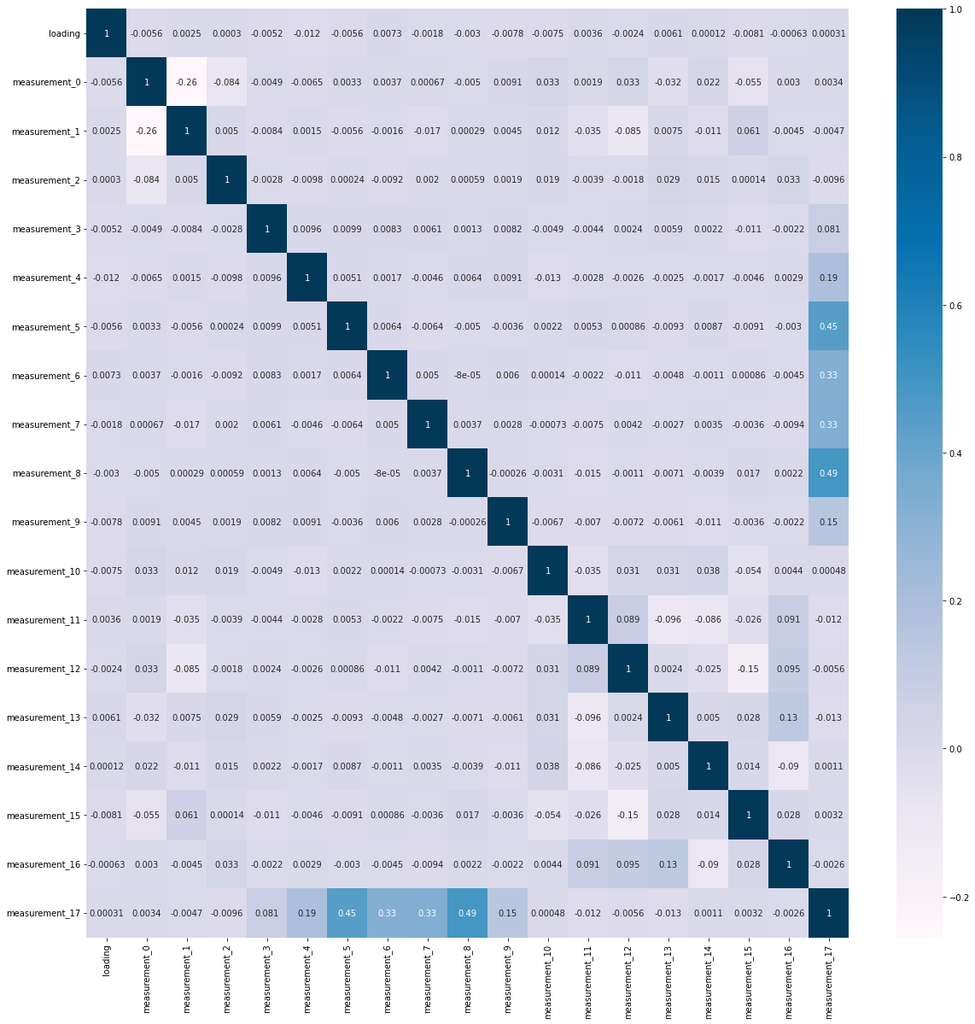

```python
# Correlation matrix
fig = plt.figure(figsize=(20, 20))
correlations = df_features_train.corr(method='pearson')
sns.heatmap(correlations, annot=True, cmap=plt.cm.PuBu)
plt.show()
```

```python
if NOTIFY_STATUS: status_notify("Task 2 - Summarize and Visualize Data completed! " + datetime.now().strftime('%a %B %d, %Y %I:%M:%S %p'))
```

## Task 3 - Pre-process Data

```python
if NOTIFY_STATUS: status_notify("Task 3 - Pre-process Data has begun! " + datetime.now().strftime('%a %B %d, %Y %I:%M:%S %p'))
```

### 3.a) Feature Scaling

```python
# Compose pipeline for the numerical and categorical features (Block #1 of 2)
numeric_columns = df_features_train.select_dtypes(include=['int64','float64']).columns
numeric_transformer = Pipeline(steps=[
    ('imputer', impute.SimpleImputer(strategy="constant", fill_value=0)),
    ('scaler', preprocessing.MinMaxScaler())
])
categorical_columns = df_features_train.select_dtypes(include=['object','bool','category']).columns
categorical_transformer = Pipeline(steps=[
    ('imputer', impute.SimpleImputer(strategy='constant', fill_value='UKNOWN')),
    ('onehot', preprocessing.OneHotEncoder(sparse=False, handle_unknown='ignore'))
])

print("Number of numerical columns:", len(numeric_columns))
print("Number of categorical columns:", len(categorical_columns))
print("Total number of columns in the feature dataframe:", df_features_train.shape[1])
```

```
Number of numerical columns: 19
Number of categorical columns: 5
Total number of columns in the feature dataframe: 24
```

```python
# Compose pipeline for the numerical and categorical features (Block #2 of 2)
preprocessor = compose.ColumnTransformer(transformers=[
    ('num', numeric_transformer, numeric_columns),
    ('cat', categorical_transformer, categorical_columns)
])

# Display the shapes of the training dataset for final inspection
array_features_train = preprocessor.fit_transform(df_features_train)
print("Transformed features from df_features_train.shape: {} to array_features_train.shape: {}".format(df_features_train.shape, array_features_train.shape))
```

```
Transformed features from df_features_train.shape: (26570, 24) to array_features_train.shape: (26570, 37)
```

```python
# Finalize the training dataset for the modeling activities
array_features_train = preprocessor.fit_transform(df_features_train)
label_encoder = preprocessing.LabelEncoder()
array_target_train = label_encoder.fit_transform(df_target_train)
print("array_features_train.shape: {} array_target_train.shape: {}".format(array_features_train.shape, array_target_train.shape))
```

```
array_features_train.shape: (26570, 37) array_target_train.shape: (26570,)
```

### 3.b) Training Data Balancing

```python
# Perform SMOTE transformation on the training data (Block #1 of 2)
X_train_imbal = array_features_train
y_train_imbal = array_target_train
print("X_train_imbal.shape: {} y_train_imbal.shape: {}".format(X_train_imbal.shape, y_train_imbal.shape))
```

```
X_train_imbal.shape: (26570, 37) y_train_imbal.shape: (26570,)
```

```python
# Perform SMOTE transformation on the training data (Block #2 of 2)
print ('Original class distribution - 1: {} | 0: {}'.format((array_target_train==1).sum(), (array_target_train==0).sum()))
# over_sample = SMOTE(sampling_strategy=0.5, random_state=RNG_SEED)
under_sample = RandomUnderSampler(sampling_strategy=0.5, random_state=RNG_SEED)
# steps = [('o', over_sample), ('u', under_sample)]
steps = [('u', under_sample)]
sample_pipeline = Pipeline(steps=steps)
array_features_train, array_target_train = sample_pipeline.fit_resample(X_train_imbal, y_train_imbal)
print ('Resampled class distribution - 1: {} | 0: {}'.format((array_target_train==1).sum(), (array_target_train==0).sum()))
```

```
Original class distribution - 1: 5649 | 0: 20921
Resampled class distribution - 1: 5649 | 0: 11298
```

### 3.c) Feature Selection

```python
# Not applicable for this iteration of the project
```

### 3.d) Display the Final Datasets for Model-Building

```python
# Finalize the training dataset for the modeling activities
# array_target_train = keras.utils.to_categorical(label_encoder.fit_transform(df_target_train))
# label_encoder = preprocessing.LabelEncoder()
# array_target_train = label_encoder.fit_transform(df_target_train)
print("array_features_train.shape: {} array_target_train.shape: {}".format(array_features_train.shape, array_target_train.shape))
```

```
array_features_train.shape: (16947, 37) array_target_train.shape: (16947,)
```

```python
if NOTIFY_STATUS: status_notify("Task 3 - Pre-process Data completed! " + datetime.now().strftime('%a %B %d, %Y %I:%M:%S %p'))
```

## Task 4 - Train and Tune Models

```python
if NOTIFY_STATUS: status_notify("Task 4 - Train and Tune Models has begun! " + datetime.now().strftime('%a %B %d, %Y %I:%M:%S %p'))
```

### 4.a) Set test options and evaluation metric

```python
# Define the baseline model for benchmarking
def create_nn_model(input_param=array_features_train.shape[1], output_param=NUM_CLASSES,
                    layer1_nodes=512, layer2_nodes=512, layer3_nodes=512, layer4_nodes=512, layer5_nodes=256,
                    layer1_dropout=0.25, layer2_dropout=0.25, layer3_dropout=0.25, layer4_dropout=0.25, layer5_dropout=0,
                    classifier_activation=CLASSIFIER_ACTIVATION,
                    loss_param=DEFAULT_LOSS, opt_param=DEFAULT_OPTIMIZER, metrics_param=DEFAULT_METRICS):
    nn_model = keras.Sequential([
        keras.layers.Dense(layer1_nodes, input_shape=(input_param,), activation='relu'),
        keras.layers.Dropout(layer1_dropout),
        keras.layers.Dense(layer2_nodes, activation='relu'),
        keras.layers.Dropout(layer2_dropout),
        keras.layers.Dense(layer3_nodes, activation='relu'),
        keras.layers.Dropout(layer3_dropout),
        keras.layers.Dense(layer4_nodes, activation='relu'),
        keras.layers.Dropout(layer4_dropout),
        keras.layers.Dense(layer5_nodes, activation='relu'),
        keras.layers.Dropout(layer5_dropout),
        keras.layers.Dense(output_param, activation=classifier_activation)
    ])
    nn_model.compile(loss=loss_param, optimizer=opt_param, metrics=metrics_param)
    return nn_model
```

```python
# start_time_module = datetime.now()
# tf.keras.utils.set_random_seed(RNG_SEED)
# baseline_model = create_nn_model()
# baseline_model.fit(array_features_train, array_target_train, epochs=MAX_EPOCHS, batch_size=BATCH_SIZE, verbose=1)
# print('Total time for model fitting and cross validating:', (datetime.now() - start_time_module))
```

```python
# Initialize the default model and get a baseline result
start_time_module = datetime.now()
results = list()
iteration = 0
cv = RepeatedKFold(n_splits=N_FOLDS, n_repeats=N_ITERATIONS, random_state=RNG_SEED)
for train_ix, val_ix in cv.split(array_features_train):
    feature_train, feature_validation = array_features_train[train_ix], array_features_train[val_ix]
    target_train, target_validation = array_target_train[train_ix], array_target_train[val_ix]
    tf.keras.utils.set_random_seed(RNG_SEED)
    baseline_model = create_nn_model()
    baseline_model.fit(feature_train, target_train, epochs=MAX_EPOCHS, batch_size=BATCH_SIZE, verbose=0)
    model_metric = baseline_model.evaluate(feature_validation, target_validation, verbose=0)[1]
    iteration = iteration + 1
    print('Score from iteration %d >>> %.4f' % (iteration, model_metric))
    results.append(model_metric)
validation_score = np.mean(results)
validation_variance = np.std(results)
print('Average model score from all iterations: %.4f (%.4f)' % (validation_score, validation_variance))
print('Total time for model fitting and cross validating:', (datetime.now() - start_time_module))
```

```
Score from iteration 1 >>> 0.5660
Score from iteration 2 >>> 0.5609
Score from iteration 3 >>> 0.5780
Score from iteration 4 >>> 0.5821
Score from iteration 5 >>> 0.5839
Average model score from all iterations: 0.5742 (0.0091)
Total time for model fitting and cross validating: 0:02:27.421624
```

### 4.b) Algorithm Tuning

```python
# learning_rate_reduction = ReduceLROnPlateau(monitor=TRAIN_METRIC, patience=3, verbose=1, factor=0.5, min_lr=0.00001)
# tf.keras.utils.set_random_seed(RNG_SEED)
# tune_model = create_nn_model()
# tune_model.fit(array_features_train, array_target_train, epochs=MAX_EPOCHS, batch_size=BATCH_SIZE, callbacks=[learning_rate_reduction], verbose=1)
# tune_model.summary()
```

```python
if NOTIFY_STATUS: status_notify("Task 4 - Train and Tune Models completed! " + datetime.now().strftime('%a %B %d, %Y %I:%M:%S %p'))
```

## Task 5 - Finalize Model and Make Predictions

```python
if NOTIFY_STATUS: status_notify("Task 5 - Finalize Model and Make Predictions has begun! " + datetime.now().strftime('%a %B %d, %Y %I:%M:%S %p'))
```

### 5.a) Train the Final Model

```python
FINAL_OPTIMIZER = tf.keras.optimizers.Adam(learning_rate=0.0001)
tf.keras.utils.set_random_seed(RNG_SEED)
final_model = create_nn_model(opt_param=FINAL_OPTIMIZER)
final_model.fit(array_features_train, array_target_train, epochs=MAX_EPOCHS, batch_size=BATCH_SIZE, verbose=0)
final_model.summary()
```

```
Model: "sequential_5"
_________________________________________________________________
 Layer (type)                Output Shape              Param #
=================================================================
 dense_30 (Dense)            (None, 512)               19456

 dropout_25 (Dropout)        (None, 512)               0

 dense_31 (Dense)            (None, 512)               262656

 dropout_26 (Dropout)        (None, 512)               0

 dense_32 (Dense)            (None, 512)               262656

 dropout_27 (Dropout)        (None, 512)               0

 dense_33 (Dense)            (None, 512)               262656

 dropout_28 (Dropout)        (None, 512)               0

 dense_34 (Dense)            (None, 256)               131328

 dropout_29 (Dropout)        (None, 256)               0

 dense_35 (Dense)            (None, 1)                 257

=================================================================
Total params: 939,009
Trainable params: 939,009
Non-trainable params: 0
_________________________________________________________________
```

### 5.b) Load Test Dataset and Make Predictions

```python
df_features_test = pd.read_csv(TEST_DATASET)

# Take a peek at the dataframe after import
print(df_features_test.head())
```

```
      id product_code  loading attribute_0 attribute_1  attribute_2  \
0  26570            F   119.57  material_5  material_6            6
1  26571            F   113.51  material_5  material_6            6
2  26572            F   112.16  material_5  material_6            6
3  26573            F   112.72  material_5  material_6            6
4  26574            F   208.00  material_5  material_6            6

   attribute_3  measurement_0  measurement_1  measurement_2  ...  \
0            4              6              9              6  ...
1            4             11              8              0  ...
2            4              8             12              4  ...
3            4              8             11             10  ...
4            4             14             16              8  ...

   measurement_8  measurement_9  measurement_10  measurement_11  \
```

[output cut: 21 more lines]

```python
id_column_name = df_features_test.columns[0]
df_kaggle_submission = pd.DataFrame()
df_kaggle_submission[id_column_name] = df_features_test[id_column_name]
print(df_kaggle_submission.head())
```

```
      id
0  26570
1  26571
2  26572
3  26573
4  26574
```

```python
# Dropping features
df_features_test.drop(columns=[id_column_name], inplace=True)

# Convert columns from one data type to another
df_features_test['attribute_0'] = df_features_test['attribute_0'].astype('category')
df_features_test['attribute_1'] = df_features_test['attribute_1'].astype('category')
df_features_test['attribute_2'] = df_features_test['attribute_2'].astype('category')
df_features_test['attribute_3'] = df_features_test['attribute_3'].astype('category')

# Take a peek at the dataframe after cleaning
print(df_features_test.head())
```

```
  product_code  loading attribute_0 attribute_1 attribute_2 attribute_3  \
0            F   119.57  material_5  material_6           6           4
1            F   113.51  material_5  material_6           6           4
2            F   112.16  material_5  material_6           6           4
3            F   112.72  material_5  material_6           6           4
4            F   208.00  material_5  material_6           6           4

   measurement_0  measurement_1  measurement_2  measurement_3  ...  \
0              6              9              6         19.305  ...
1             11              8              0         17.883  ...
2              8             12              4         18.475  ...
3              8             11             10         16.518  ...
4             14             16              8         17.808  ...

   measurement_8  measurement_9  measurement_10  measurement_11  \
```

[output cut: 21 more lines]

```python
# Finalize the test dataset for the testing activities
array_features_test = preprocessor.transform(df_features_test)
print("Transformed features from df_features_test.shape: {} to array_features_test.shape: {}".format(df_features_test.shape, array_features_test.shape))
```

```
Transformed features from df_features_test.shape: (20775, 24) to array_features_test.shape: (20775, 37)
```

```python
# Make batched predictions
test_predictions =  final_model.predict(array_features_test)
print(test_predictions)
```

```
[[0.40252763]
 [0.38287768]
 [0.38881353]
 ...
 [0.3247228 ]
 [0.36462575]
 [0.32320103]]
```

```python
dataset_path = 'https://dainesanalytics.com/datasets/kaggle-tabular-playground-2022aug/sample_submission.csv'
df_sample_submission = pd.read_csv(dataset_path, index_col=False)
df_sample_submission.drop(columns=[id_column_name], inplace=True)
submission_header = list(df_sample_submission.columns)[0]
print(submission_header)
```

```
failure
```

```python
df_kaggle_submission[submission_header] = test_predictions
print(df_kaggle_submission.head())
```

```
      id   failure
0  26570  0.402528
1  26571  0.382878
2  26572  0.388814
3  26573  0.404723
4  26574  0.495111
```

```python
submission_file = df_kaggle_submission.to_csv(header=True, index=False)
filename = 'submission_' + datetime.now().strftime('%Y%m%d-%H%M') + '.csv'
with open(filename, 'w') as f:
    f.write(submission_file)
    print('Completed writing output file: ' + filename)
```

```
Completed writing output file: submission_20220821-0312.csv
```

```python
if NOTIFY_STATUS: status_notify("Task 5 - Finalize Model and Make Predictions completed! " + datetime.now().strftime('%a %B %d, %Y %I:%M:%S %p'))
```

```python
print ('Total time for the script:',(datetime.now() - START_TIME_SCRIPT))
```

```
Total time for the script: 0:03:15.118904
```